# SSC imputation pipeline

# 1 Data structure

- Individuals from 2591 SSC families were genotyped on three chips. Note that members of each family were analyzed on the same array.
  - Illumina 1Mv3 Duo (1189 families), 4626 people (2703 males, 1923 females), 1199033 SNPs
  - Illumina 1Mv1 (333 families), 1354 people (801 males, 553 females), 1072814 SNPs
  - Illumina HumanOmni2.5M (1069 families), 4240 people (2490 males, 1750 females), 2440283 SNPs
  - coded with ATGC, no need to recode
  - chromosome are from chr1 to chr26, of which autosome 1-22, X:23 & 25 will be imputed (** –output-chr M can recode as X instead of 23**)
  - **SNP IDs**: pay attention to Omini2.5, (–update-name from format as SNP(chr)-pos to kgp identifiers should be done first), later kgp identifiers should be converted to rsids.
  - All individuals are included for imputation
- Imputation will be done separately for each chip.

# 2 Pre-imputation

## 2.1 Strand flip & liftover

- From build 36 to build 37, from minus strand to plus strand)
- SSC was assembled based on build 36 (confirmed with [dbSNP](https://www.ncbi.nlm.nih.gov/snp/?cmd=search))
- [strand files](https://www.well.ox.ac.uk/~wrayner/strand/)
  - Human1Mv1_C-b37.strand is used for both 1Mv1 and 1Mv3
  - HumanOmni2.5-8v1_A-b37.Source.strand is used for Omni2.5
- Check the output files from update_build.sh
  - remove chr 24
  - recode chr 23 to chr X
  - update-name for kgp identifiers in Omni2.5 (when there are a multitude of SNPs coded as kgp)

## 2.2 Genotype QC

- Filters: --geno 0.05 --hwe 1e-6 --mind 0.1 --maf 0.01.
- Then recode to .vcf files (separate autosome and X-chromosome for now)

### 2.2.1 Illumina 1Mv3

- 0 people removed due to missing genotype data (--mind).
- Total genotyping rate is 0.990957.
- 15033 variants removed due to missing genotype data (--geno).
- 126158 variants removed due to minor allele threshold(s).
- --hwe: 38392 variants removed due to Hardy-Weinberg exact test.
- **859161 variants and 4626 people pass filters and QC.**

### 2.2.2 Illumina 1Mv1

- 0 people removed due to missing genotype data (--mind).
- Total genotyping rate is 0.976306.
- 29018 variants removed due to missing genotype data (--geno).
- 136291 variants removed due to minor allele threshold(s).
- --hwe: 6476 variants removed due to Hardy-Weinberg exact test.
- **898063 variants and 1354 people pass filters and QC.**

### 2.2.3 Illumina Omni2.5M

- 0 people removed due to missing genotype data (--mind).
- Total genotyping rate is 0.99696.
- 7885 variants removed due to missing genotype data (--geno).
- 723923 variants removed due to minor allele threshold(s).
- --hwe: 53449 variants removed due to Hardy-Weinberg exact test.
- **1575751 variants and 4240 people pass filters and QC.**

## 2.3 Check and fix the REF allele

- only for sanger imputation server
- using bcftools
- check with HRC build37

**The whole pre-Imputation QC process stored in /gpfs1/scratch/group30days/cnsg_park/uqywan/auti/scripts/ssc_preImp_QC.R**

## 2.4 Submit for imputation

- [Sanger imputation server](https://imputation.sanger.ac.uk)
- Using Globus to transfer files (##sanger to ##flash)
- HRC reference & Eagle v2.4 for phasing

# 3 After Imputation

- recode .vcf to plink format
- extract info scores in .info
- fill missing SNP IDs in .bim/.info
- update .fam file in case there are two "_" in the FID_IID
- QC for each chip (filters: --info 0.03)
  - 1Mv1: 29,613,517 SNPs left
  - 1Mv3: 31,605,064 SNPs left
  - Omni2.5: 30,466,266 SNPs left
  - 23,460,315 SNPs overlapped
- merge .bfile of three chips
  - remaining 22,274,458 SNPs after QC for --geno 0.05 --mac 1 --hwe 1e-6
  - remaining 7,480,061 SNPs after QC for --geno 0.05 --maf 0.01 --hwe 1e-6

## 3.1 Frequency distrubtion

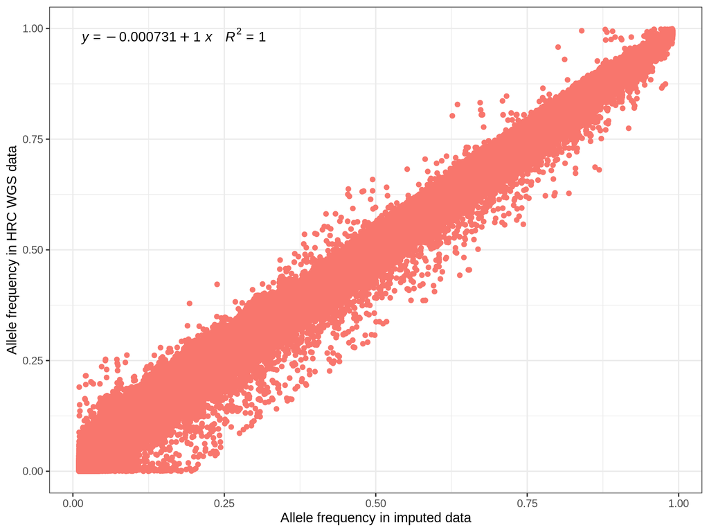

## 3.2 PCA

- Project the first 3 PCs based on pruned HapMap3 SNPs onto 1000G
- Using K-means to calculate distance
- Assign ancestry based on posterior probability 0.9

### 3.2.1 All individuals

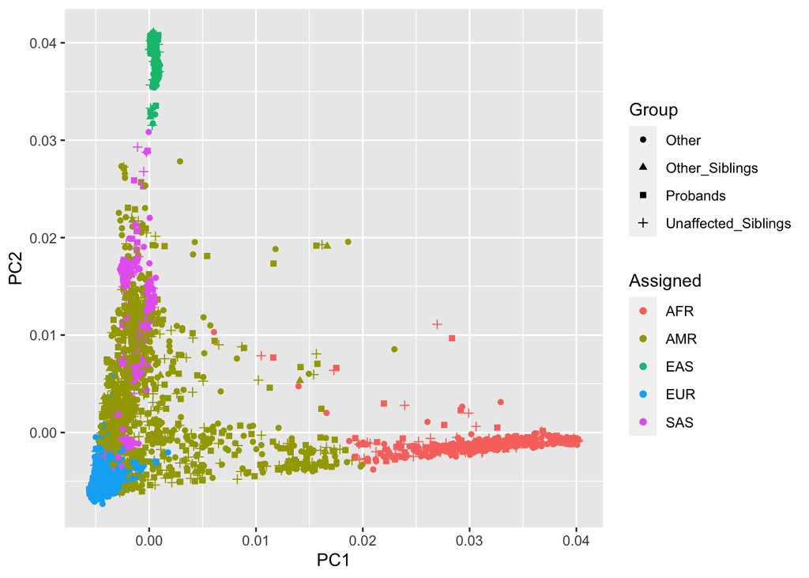

```r
toAssign <- read.table("../outputs/ssc_anc.txt", header = T, stringsAsFactors = F)

#pca_all <-
ggplot(data = toAssign, aes(x = PC1, y = PC2, color = Assigned, shape = Group)) +
  geom_point() +
  ylab("PC2") +
  xlab("PC1")
```

### 3.2.2 Probands only

#### 3.2.2.1 Self Reported VS Ancestry Assigned

```r
toAssign1 <- read.table("../outputs/proband_anc.txt", header = T, stringsAsFactors = F)
kable(table(toAssign1$Self_Reported, toAssign1$Assigned))
```

|  | AFR | AMR | EAS | EUR | SAS |
| --- | --- | --- | --- | --- | --- |
| african-amer | 91 | 7 | 0 | 0 | 1 |
| asian | 0 | 1 | 60 | 0 | 47 |
| more-than-one-race | 11 | 100 | 2 | 44 | 45 |
| native-american | 0 | 4 | 0 | 1 | 0 |
| native-hawaiian | 0 | 0 | 1 | 1 | 0 |
| not-specified | 1 | 16 | 0 | 2 | 0 |
| other | 4 | 91 | 0 | 14 | 12 |
| white | 1 | 116 | 0 | 1907 | 8 |

#### 3.2.2.2 PCA plot based on assigned ancestry

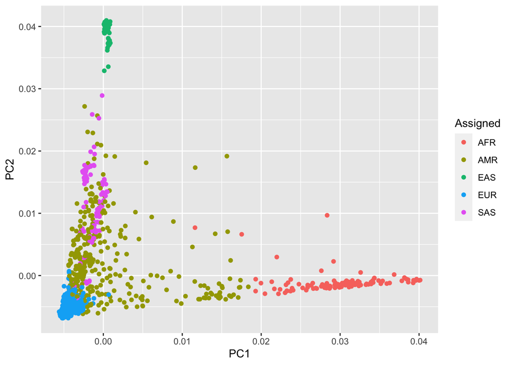

```r
#pca_prob <-
ggplot(data = toAssign1, aes(x = PC1, y = PC2, color = Assigned)) +
  geom_point() +
  ylab("PC2") +
  xlab("PC1")
```

## 3.3 Relatedness in Probands

- Generate GRM based on LD pruned SNPs
- 2206 probands with pairwise GRM < 0.05

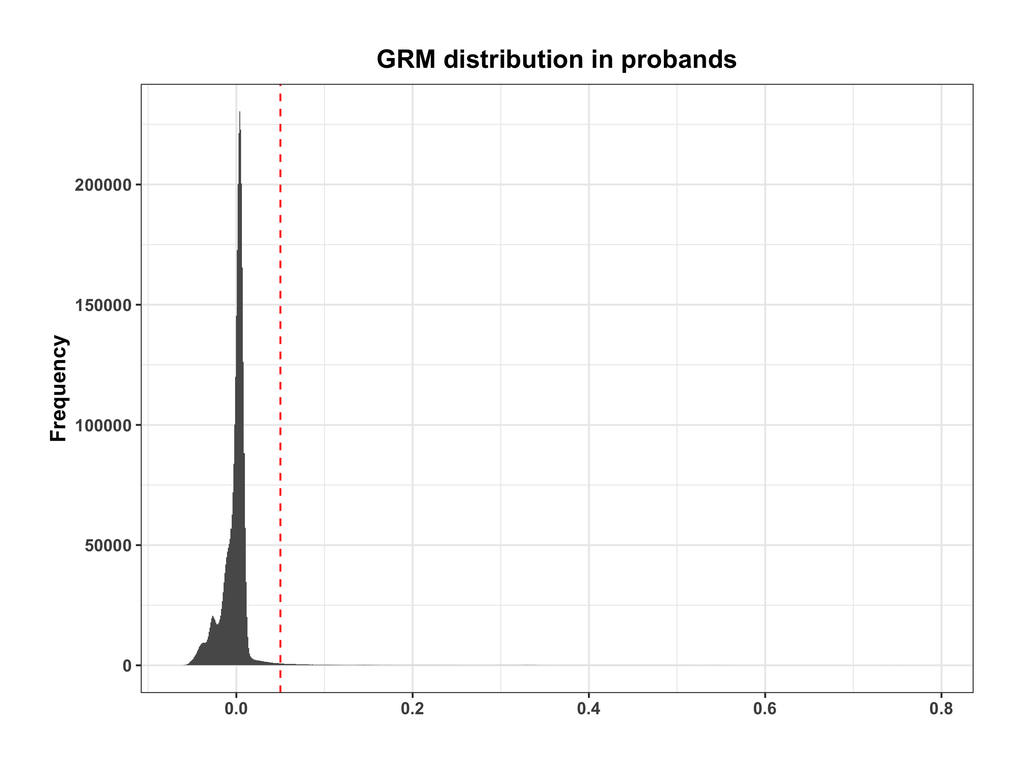

**The whole process stored in /gpfs1/scratch/group30days/cnsg_park/uqywan/auti/scripts/afterImp_QC*.R**